# Problem Set 3

Author

Diego Carpenter

Published

October 31, 2026

**GitHub repo:** https://github.com/DiegoCarpenter/ec422_ps3_carpenter.git

```r
library(tidyverse)
library(fpp3)
```

## Time and Tsibbles

### The two datasets

```r
# 2.2a: let read_csv() guess the column types
retail_guess <- read_csv("data/retail_sales_raw.csv")
head(retail_guess)
```

```
# A tibble: 6 × 3
  observation_date  RSAFS RSAFSNA
  <date>            <dbl>   <dbl>
1 1992-01-01       159177  142051
2 1992-02-01       159189  142498
3 1992-03-01       158647  154439
4 1992-04-01       159921  158430
5 1992-05-01       160471  164788
6 1992-06-01       161205  163417
```

```r
# 2.2b: re-read with explicit column types, treating FRED's "." as missing
retail_raw <- read_csv(
  "data/retail_sales_raw.csv",
  na = ".",
  col_types = cols(
    observation_date = col_date(format = "%Y-%m-%d"),
    RSAFS = col_double(),
    RSAFSNA = col_double()
  )
)

# 2.3a: wide -> long
retail_raw_long <- retail_raw |>
  select(observation_date, RSAFS, RSAFSNA) |>
  pivot_longer(cols = c(RSAFS, RSAFSNA), names_to = "series_id", values_to = "sales")
head(retail_raw_long)
```

```
# A tibble: 6 × 3
  observation_date series_id  sales
  <date>           <chr>      <dbl>
1 1992-01-01       RSAFS     159177
2 1992-01-01       RSAFSNA   142051
3 1992-02-01       RSAFS     159189
4 1992-02-01       RSAFSNA   142498
5 1992-03-01       RSAFS     158647
6 1992-03-01       RSAFSNA   154439
```

```r
# 2.4a: build the tsibble
retail_ts <- retail_raw_long |>
  mutate(Month = yearmonth(observation_date)) |>
  as_tsibble(index = Month, key = series_id)

# 2.4b
head(retail_ts)
```

```
# A tsibble: 6 x 4 [1M]
# Key:       series_id [1]
  observation_date series_id  sales    Month
  <date>           <chr>      <dbl>    <mth>
1 1992-01-01       RSAFS     159177 1992 Jan
2 1992-02-01       RSAFS     159189 1992 Feb
3 1992-03-01       RSAFS     158647 1992 Mar
4 1992-04-01       RSAFS     159921 1992 Apr
5 1992-05-01       RSAFS     160471 1992 May
6 1992-06-01       RSAFS     161205 1992 Jun
```

```r
has_gaps(retail_ts)
```

```
# A tibble: 2 × 2
  series_id .gaps
  <chr>     <lgl>
1 RSAFS     FALSE
2 RSAFSNA   FALSE
```

```r
# 2.5a
head(canadian_gas)
```

```
# A tsibble: 6 x 2 [1M]
     Month Volume
     <mth>  <dbl>
1 1960 Jan   1.43
2 1960 Feb   1.31
3 1960 Mar   1.40
4 1960 Apr   1.17
5 1960 May   1.12
6 1960 Jun   1.01
```

```r
key_vars(canadian_gas)
```

```
character(0)
```

```r
index_var(canadian_gas)
```

```
[1] "Month"
```

```r
# 2.5b
can_gas <- canadian_gas |>
  select(Month, Volume)
has_gaps(can_gas)
```

```
# A tibble: 1 × 1
  .gaps
  <lgl>
1 FALSE
```

```r
head(can_gas)
```

```
# A tsibble: 6 x 2 [1M]
     Month Volume
     <mth>  <dbl>
1 1960 Jan   1.43
2 1960 Feb   1.31
3 1960 Mar   1.40
4 1960 Apr   1.17
5 1960 May   1.12
6 1960 Jun   1.01
```

**can_gas** This is a working copy of the `canadian_gas` tsibble. It holds monthly natural gas production in Canada in billions of cubic meters from January 1960 to February 2005.

**2.2a.** When `read_csv()` guessed, `observation_date` came in as class `<Date>`.

### Working with dates (2.6)

```r
# 2.6a
can_gas_recent <- can_gas |>
  filter(Month >= yearmonth("1990 Jan"))
head(can_gas_recent)
```

```
# A tsibble: 6 x 2 [1M]
     Month Volume
     <mth>  <dbl>
1 1990 Jan   12.5
2 1990 Feb   11.2
3 1990 Mar   11.6
4 1990 Apr   11.1
5 1990 May   11.0
6 1990 Jun   10.1
```

```r
# 2.6b
can_gas_recent <- can_gas_recent |>
  mutate(year    = year(Month),
         month   = month(Month, label = TRUE),
         quarter = quarter(Month))

monthly_avg <- can_gas_recent |>
  as_tibble() |>
  group_by(month) |>
  summarize(avg_volume = mean(Volume))
monthly_avg |> knitr::kable(digits = 2)
```

| month | avg_volume |
| --- | --- |
| Jan | 16.99 |
| Feb | 15.28 |
| Mar | 16.34 |
| Apr | 15.74 |
| May | 15.75 |
| Jun | 14.94 |
| Jul | 15.60 |
| Aug | 15.62 |
| Sep | 15.13 |
| Oct | 16.16 |
| Nov | 16.18 |
| Dec | 17.15 |

```r
# 2.6c
can_gas_recent |>
  mutate(next_month           = Month + 1,
         same_month_last_year = Month - 12) |>
  head()
```

```
# A tsibble: 6 x 7 [1M]
     Month Volume  year month quarter next_month same_month_last_year
     <mth>  <dbl> <dbl> <ord>   <int>      <mth>                <mth>
1 1990 Jan   12.5  1990 Jan         1   1990 Feb             1989 Jan
2 1990 Feb   11.2  1990 Feb         1   1990 Mar             1989 Feb
3 1990 Mar   11.6  1990 Mar         1   1990 Apr             1989 Mar
4 1990 Apr   11.1  1990 Apr         2   1990 May             1989 Apr
5 1990 May   11.0  1990 May         2   1990 Jun             1989 May
6 1990 Jun   10.1  1990 Jun         2   1990 Jul             1989 Jun
```

**2.6b.** Since 1990, **Dec** has the highest average production, with January almost as high. **Jun** has the lowest. So this means production is highest in winter and lowest in summer.

**2.6c.** Because `Month` is a `yearmonth`, `Month + 1` moves forward one month, and `Month - 12` moves back to the same month a year earlier. Adding 1 to an ordinary `Date` would move forward one day.

```r
# 2.6d
can_gas_q <- can_gas |>
  filter(Month <= yearmonth("2004 Dec")) |>
  index_by(Quarter = yearquarter(Month)) |>
  summarize(Volume = sum(Volume))

head(can_gas_q)
```

```
# A tsibble: 6 x 2 [1Q]
  Quarter Volume
    <qtr>  <dbl>
1 1960 Q1   4.14
2 1960 Q2   3.30
3 1960 Q3   2.97
4 1960 Q4   4.26
5 1961 Q1   5.01
6 1961 Q2   4.17
```

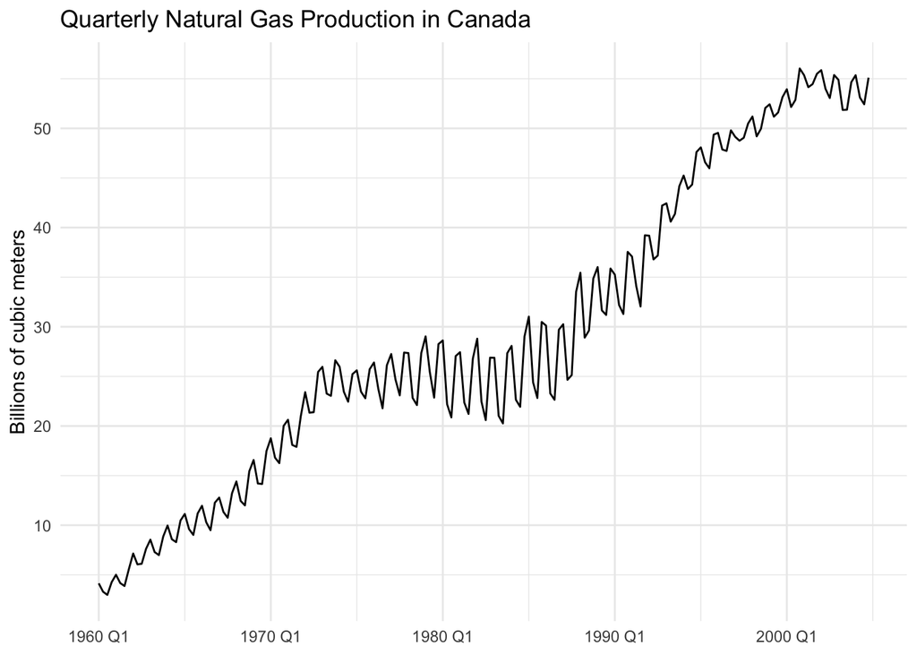

```r
can_gas_q |>
  autoplot(Volume) +
  labs(title = "Quarterly Natural Gas Production in Canada",
       x = NULL, y = "Billions of cubic meters") +
  theme_minimal()
```

**2.6d.** Gas production is a *flow*. It is the amount produced during each month. A quarter’s production is the total of its three months, so you `sum()`. Taking the `mean()` would give average *monthly* production. The quarterly series is still seasonal.

### Plotting with autoplot() (2.7)

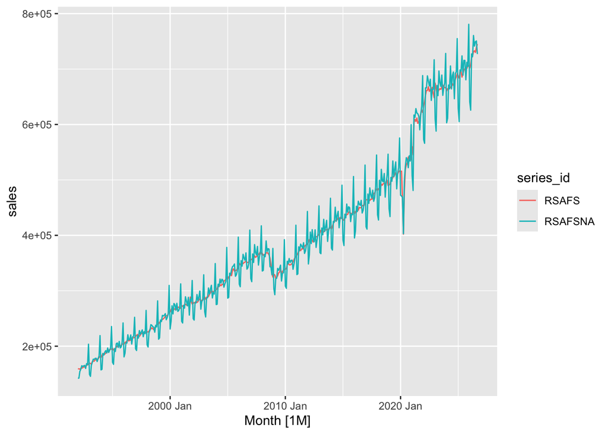

```r
# 2.7a
retail_ts |> autoplot(sales)
```

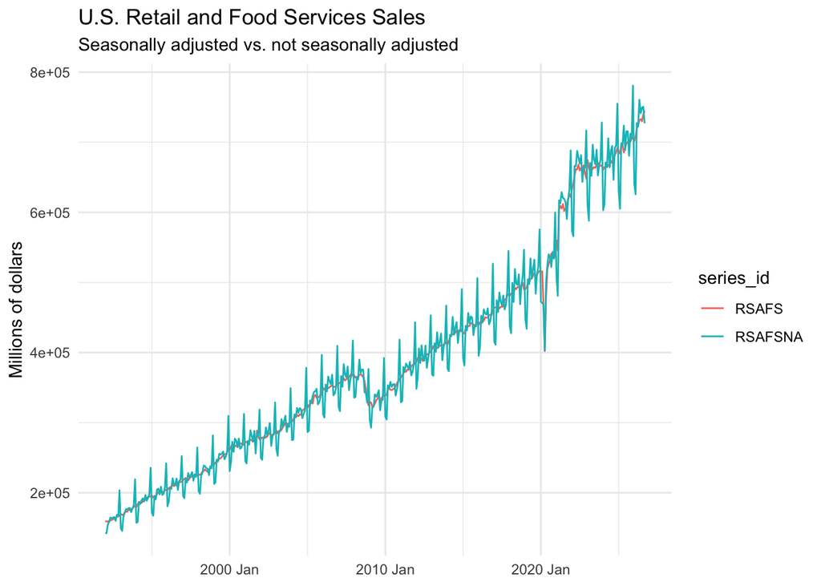

```r
# 2.7b
retail_ts |>
  autoplot(sales) +
  labs(
    title = "U.S. Retail and Food Services Sales",
    subtitle = "Seasonally adjusted vs. not seasonally adjusted",
    x = NULL, y = "Millions of dollars", color = NULL
  ) +
  theme_minimal()
```

**2.7b.** The NSA series has a sharp spike every December, then a big drop in January and February. The SA series has none of these repeating spikes and runs smoothly through the middle of the NSA line. Over the long run, the two series follow the same path. Seasonal adjustment only remove the regular within-year pattern. It doesn’t change the trend or the business cycle.

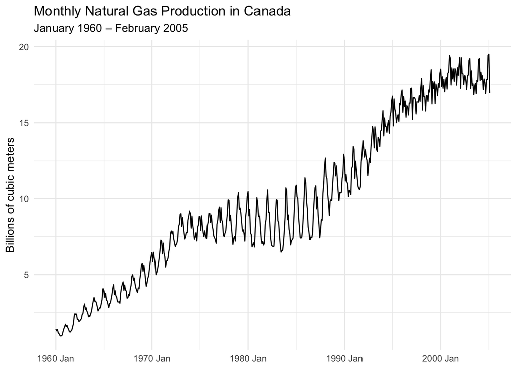

```r
# 2.7c
can_gas |>
  autoplot(Volume) +
  labs(
    title = "Monthly Natural Gas Production in Canada",
    subtitle = "January 1960 – February 2005",
    x = NULL, y = "Billions of cubic meters"
  ) +
  theme_minimal()
```

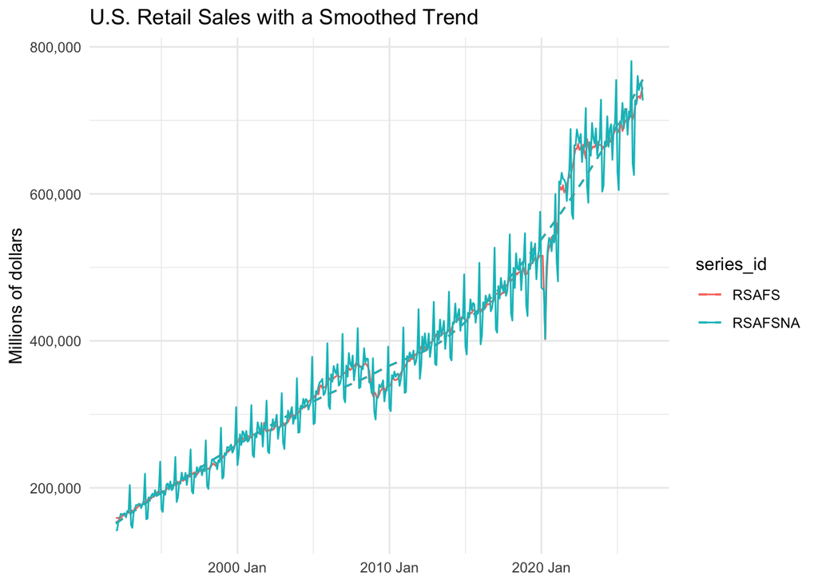

```r
# 2.7d
retail_ts |>
  autoplot(sales) +
  geom_smooth(method = "loess", se = FALSE, linetype = "dashed", linewidth = 0.6) +
  scale_y_continuous(labels = scales::label_comma()) +
  labs(
    title = "U.S. Retail Sales with a Smoothed Trend",
    x = NULL, y = "Millions of dollars", color = NULL
  ) +
  theme_minimal()
```

**2.7d.** I added a dashed `geom_smooth()` trend line for each series to show the long-run path without the monthly wiggles.

## Transformations

### Logs (3.1)

| period | Avg. within-year range (level) | Avg. within-year range (log) |
| --- | --- | --- |
| 1960–64 | 1.01 | 0.46 |
| 1980–89 | 3.76 | 0.41 |
| 1995–2004 | 2.18 | 0.13 |

**3.1a.** Only partly. From the 1960s through the 1980s, the seasonal swings get bigger as production rises: the average within-year range grows from about 1 billion to almost 4 billion. That’s the pattern that calls for logs. It doesn’t hold over the whole sample, though. After about 1990, production keeps rising, but the swings get *smaller*, down to roughly 2 billion m³ after 1995.

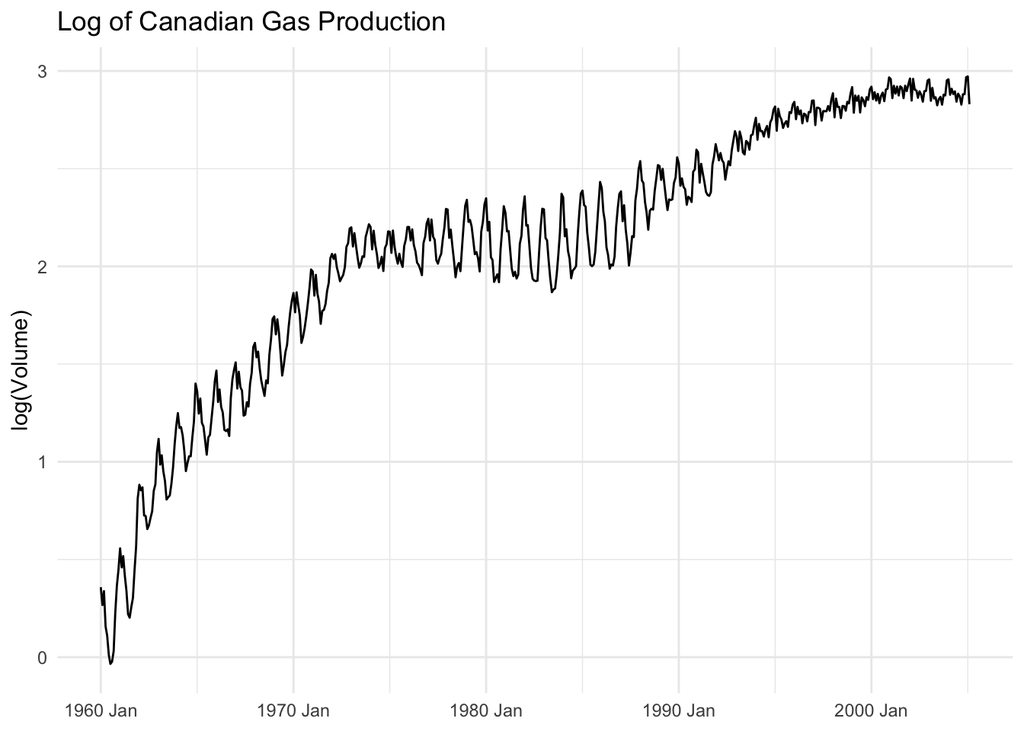

```r
# 3.1b
can_gas <- can_gas |>
  mutate(log_volume = log(Volume))

can_gas |>
  autoplot(log_volume) +
  labs(title = "Log of Canadian Gas Production", x = NULL, y = "log(Volume)") +
  theme_minimal()
```

**3.1b.** In logs, the trend becomes concave. Growth is very fast in the early 1960s, slower afterward, and nearly flat after 2000. The seasonal swings look *largest* at the start of the sample and shrink steadily. So logs don’t make the seasonal swings constant. But they’re not a clear win for stabilizing the seasonality. The problem is that the seasonal pattern itself changes over time.

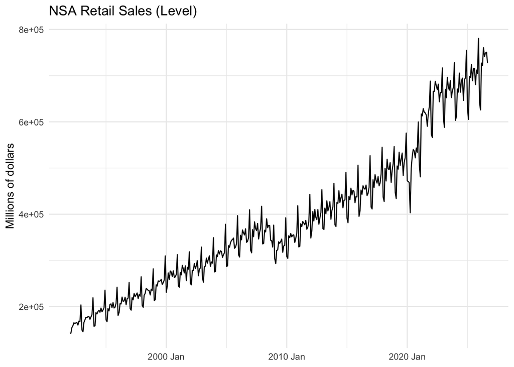

```r
# 3.1c
retail_nsa <- retail_ts |>
  filter(series_id == "RSAFSNA") |>
  mutate(log_sales = log(sales))

retail_nsa |>
  autoplot(sales) +
  labs(title = "NSA Retail Sales (Level)", x = NULL, y = "Millions of dollars") +
  theme_minimal()
```

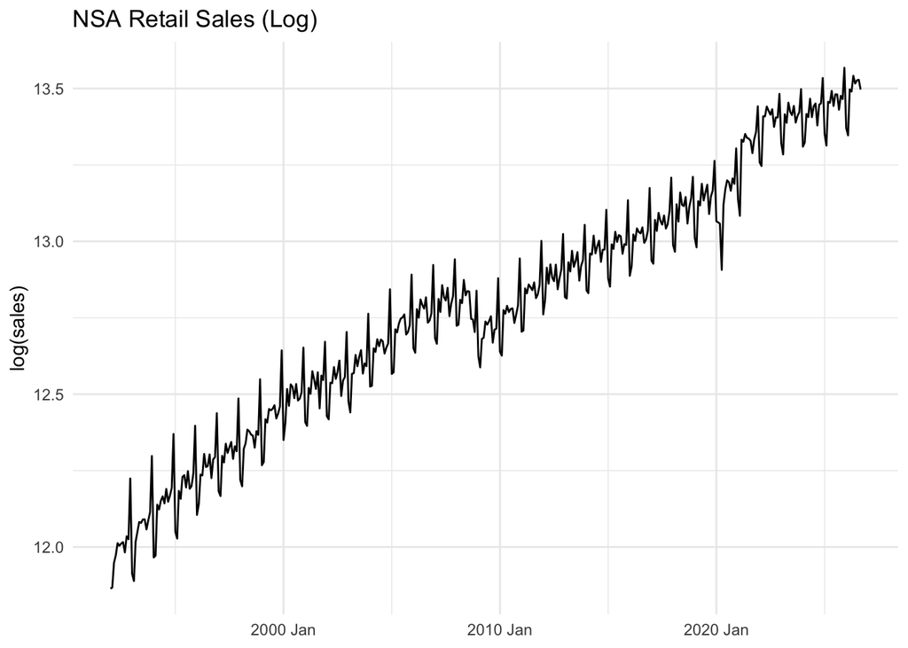

```r
retail_nsa |>
  autoplot(log_sales) +
  labs(title = "NSA Retail Sales (Log)", x = NULL, y = "log(sales)") +
  theme_minimal()
```

**3.1c.** The case for logging is **stronger** for retail sales than for can_gas. After taking the logs, the trend is close to a straight line and the seasonal swings are much more even in size across the sample.

### Growth rates (3.2)

The month-over-month growth rate, computed two ways:

$$g^{\text{direct}}_t = 100 \times \frac{\text{Volume}_t - \text{Volume}_{t-1}}{\text{Volume}_{t-1}}
\qquad\qquad
g^{\text{log}}_t = 100 \times \big(\log \text{Volume}_t - \log \text{Volume}_{t-1}\big)$$

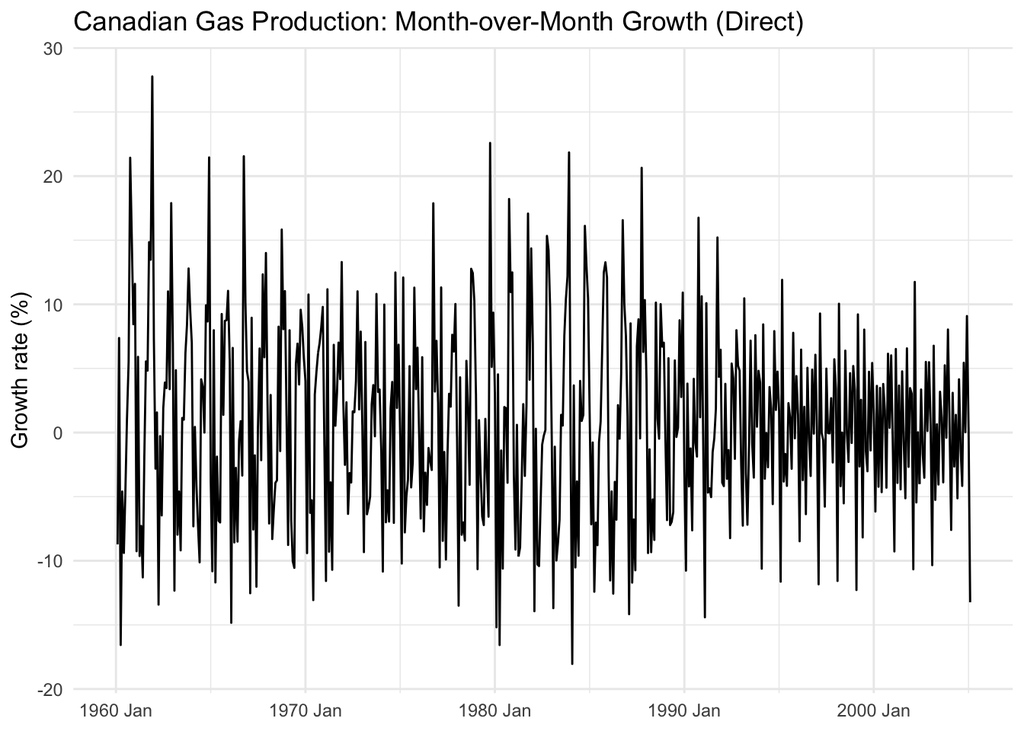

```r
# 3.2a
can_gas <- can_gas |>
  mutate(
    growth_direct  = 100 * difference(Volume) / lag(Volume),
    growth_logdiff = 100 * difference(log_volume)
  )

can_gas |>
  autoplot(growth_direct) +
  labs(title = "Canadian Gas Production: Month-over-Month Growth (Direct)",
       x = NULL, y = "Growth rate (%)") +
  theme_minimal()
```

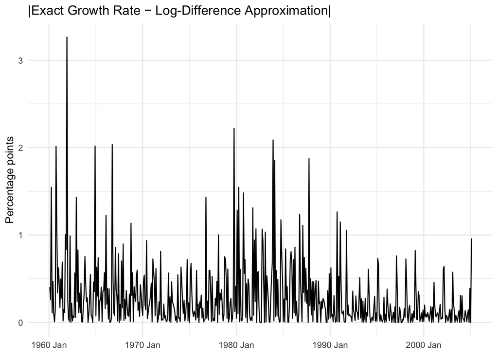

```r
can_gas <- can_gas |>
  mutate(growth_gap = abs(growth_direct - growth_logdiff))

can_gas |>
  autoplot(growth_gap) +
  labs(title = "|Exact Growth Rate − Log-Difference Approximation|",
       x = NULL, y = "Percentage points") +
  theme_minimal()
```

**3.2a.** The log-difference approximation is very good for a typical month. The median gap is 0.14 percentage points and the mean is 0.28, compared with a typical absolute growth rate of about 5.4%. It gets worse only in the few months with very large moves: the biggest gap is 3.26 points, during the large swings of the early 1960s, because the approximation error grows with the size of the change.

### SA vs. NSA growth rates (3.3)

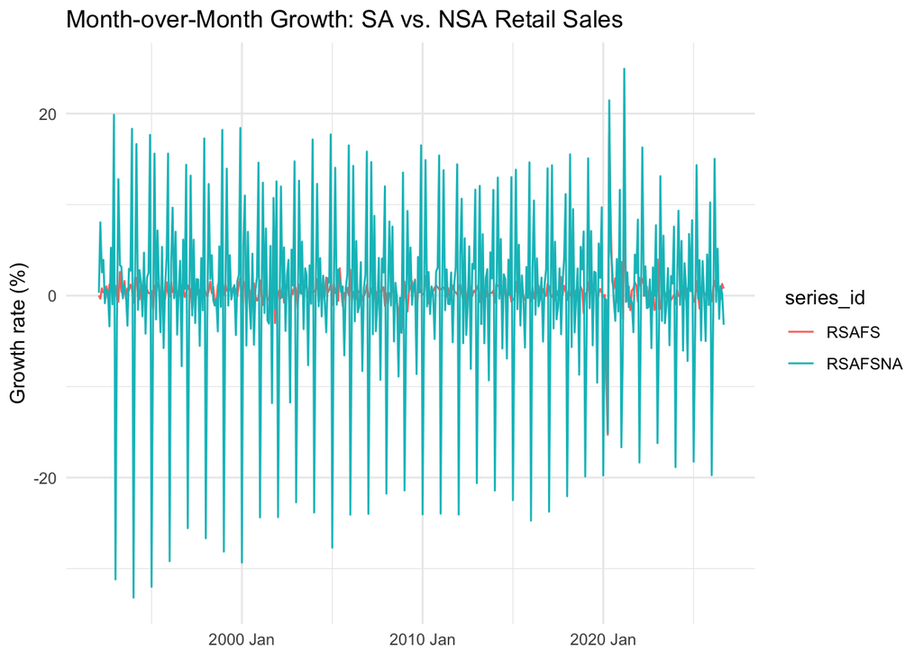

```r
retail_ts <- retail_ts |>
  group_by_key() |>
  mutate(growth_mom = 100 * difference(log(sales))) |>
  ungroup()

retail_ts |>
  autoplot(growth_mom) +
  labs(
    title = "Month-over-Month Growth: SA vs. NSA Retail Sales",
    x = NULL, y = "Growth rate (%)", color = NULL
  ) +
  theme_minimal()
```

```r
growth_sd <- retail_ts |>
  as_tibble() |>
  group_by(series_id) |>
  summarize(`SD of monthly growth (%)` = sd(growth_mom, na.rm = TRUE))
growth_sd |> knitr::kable(digits = 2)
```

| series_id | SD of monthly growth (%) |
| --- | --- |
| RSAFS | 1.70 |
| RSAFSNA | 9.57 |

**3.3.** NSA growth is far noisier. Its standard deviation is 9.6 percentage points, versus 1.7 for the SA series. The NSA growth rate jumps up every November–December and falls sharply every January. Those same holiday spikes and post-holiday drops from 2.7b dominate its month-to-month changes. The SA series has that pattern removed, so its growth rate mostly stays within a percent or two of zero, and big moves show up only for real, non-seasonal events like the spring 2020 collapse and rebound.

## Seasonality

### Season plots (4.1)

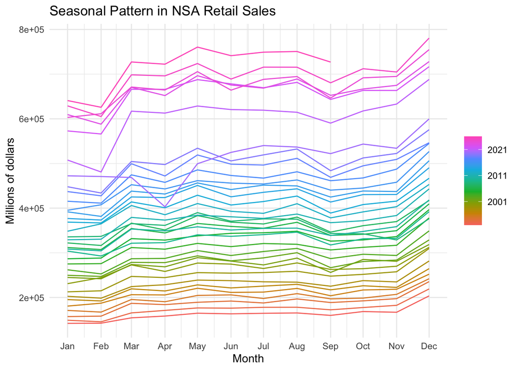

```r
# 4.1a
retail_ts |>
  filter(series_id == "RSAFSNA") |>
  gg_season(sales) +
  labs(title = "Seasonal Pattern in NSA Retail Sales", y = "Millions of dollars") +
  theme_minimal()
```

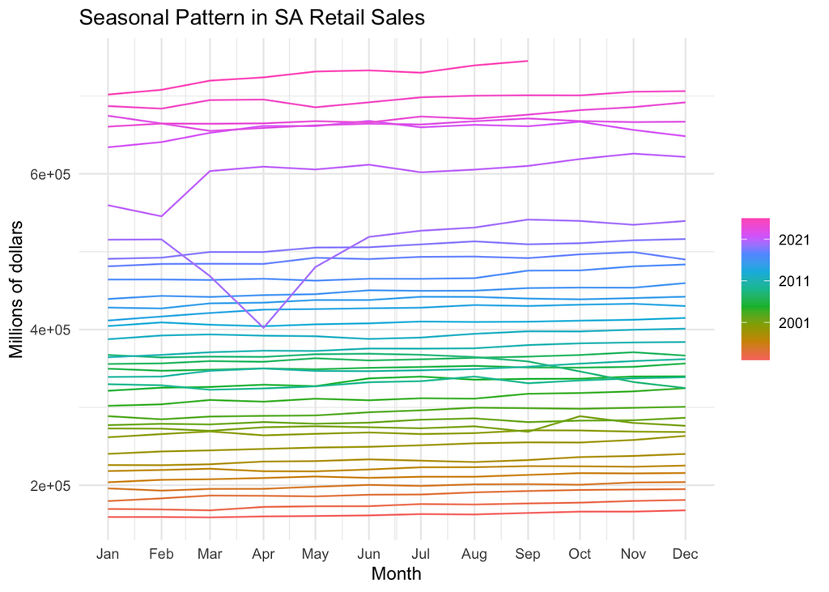

```r
# 4.1b
retail_ts |>
  filter(series_id == "RSAFS") |>
  gg_season(sales) +
  labs(title = "Seasonal Pattern in SA Retail Sales", y = "Millions of dollars") +
  theme_minimal()
```

**4.1b.** In the NSA season plot, every year traces the same shape: low in January and February, rising through spring, and a big jump in December. In the SA season plot, each year’s line is basically flat (rising only slightly from the trend within the year), with no December spike. The SA series is the NSA series with that repeating within-year shape estimated and removed. The only dips that remain are non-seasonal events like spring 2020.

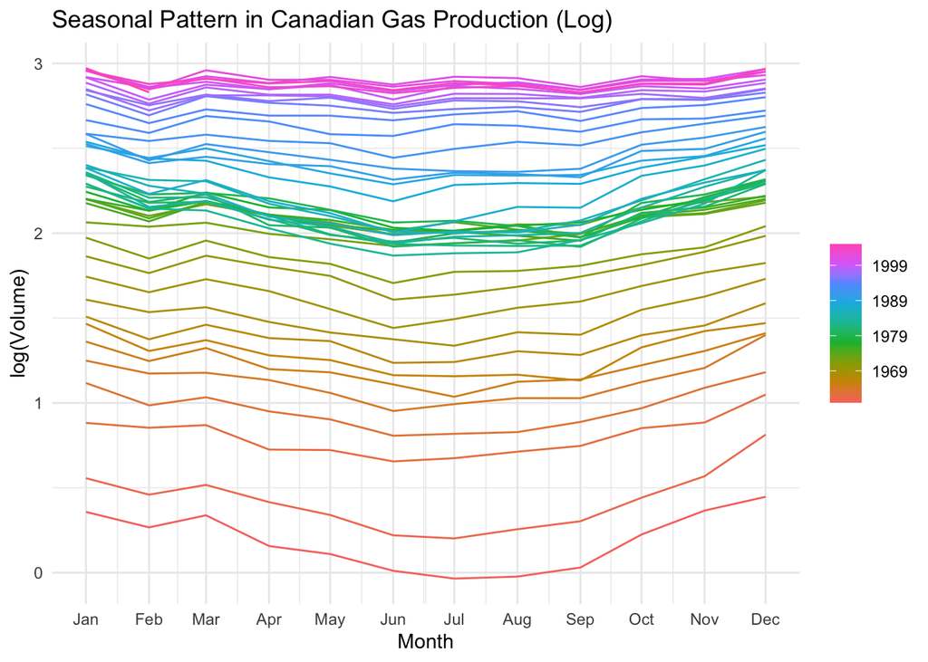

```r
# 4.1c
can_gas |>
  gg_season(log_volume) +
  labs(title = "Seasonal Pattern in Canadian Gas Production (Log)", y = "log(Volume)") +
  theme_minimal()
```

**4.1c.** Production is high in the winter months (December, January, and March) and low in summer (June through September). That matches intuition: natural gas is used heavily for heating during Canada’s cold winters, so producers pump more when demand peaks. The plot also shows the pattern getting weaker over time, with the lines for the late 1990s and 2000s nearly flat.